# Implications of animal movement rate variation in spatial patterns of seed dispersal

Javiera Rudolph

# Figure 1

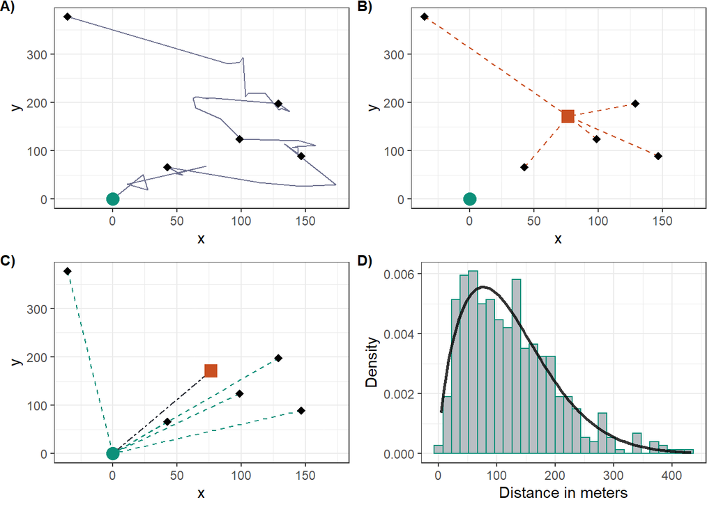

**Figure1** - Simulation process overview and seed dispersal measures. Panels A through C represent one simulation run, whereas panel D shows the results from 100 simulation runs. A) An animal starts at the origin (coordinates (0,0) represented by the teal dot) where it ingests five seeds. The animal moves in the landscape (grey trajectory path) and drops seeds (black diamonds) as it reaches their gut retention time. B) The mean seed location per run is calculated and shown in the orange square. The distance of each seed to the mean location is used to calculate seed dispersion as described in the main text. C) Average seed dispersal per run (black dashed line) is calculated as the distance from the origin (teal dot) to the mean seed location (orange square). Seed dispersal distance for each seed (teal dashed lines) are calculated as the distance of each seed from the origin. D) Seed dispersal distances for each seed in 100 simulation runs are used to generate a seed dispersal distance histogram. A Weibull distribution is fit to the data to describe the seed dispersal kernel.

# Table 1

**Table1** - Movement rates for the twelve tagged individuals from data collected by Holbrook (2011). Movement rate for individuals is calculated as the distance moved in meters per minute for every movement bout, averaged across all observations during the tracking period. In the case of social groups, the movement rate is calculated as the average for all movement bouts across all individuals belonging to that social group. Movement rate units are in meters displaced per minute.

```
## # A tibble: 12 x 5
## # Groups:   Bird_ID [12]
##    Bird_ID   obs movrate fam_g famrate
##    <fct>   <int>   <dbl> <chr>   <dbl>
##  1 1          42    30   f1       40.1
##  2 3          76    41.9 f1       40.1
##  3 5          42    47.1 f1       40.1
##  4 7          68    25   f2       25
##  5 13         58    31.2 f3       29.4
##  6 19         53    27.3 f3       29.4
##  7 22         43    27.8 f4       27.8
##  8 28         38    17.9 f5       17.9
##  9 49         84    20.2 f6       26.1
## 10 84         80    32.2 f6       26.1
## 11 29         32    20.9 f7       16.5
## 12 30         48    13.6 f7       16.5
```

# Figure 2

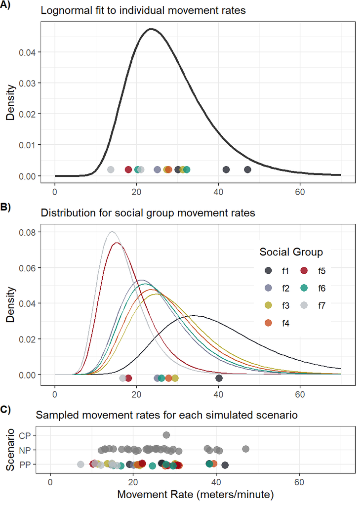

**Figure 2** - Fitted distributions to movement rate data from estimated from radiotracking. A) lognormal distribution fitted to the twelve data points of movement rate. B) Lognormal distributions used to describe movement rates for each social group. We used the movement rate of each family group, shown by the colored dots across the x axis, as the meanlog parameter in each lognormal distribution. Due to data constraints, we used the estimated sdlog parameter from panel A to generate movement rate curves from panel B. C) movement rates used for each of the pooling scenarios. In the case of complete pooling (cp), estimated parameters from the lognormal distribution in panel A were used to calculate the expected value and this was used as the movement rate for cp. In the case of no pooling (np) we randomly sampled 30 movement rates from the distribution fitted in panel A. In the case of partial pooling (pp), we randomly sampled 6 movement rates from each social group’s curve and used these for the partial pooling simulations.

# Figure 3

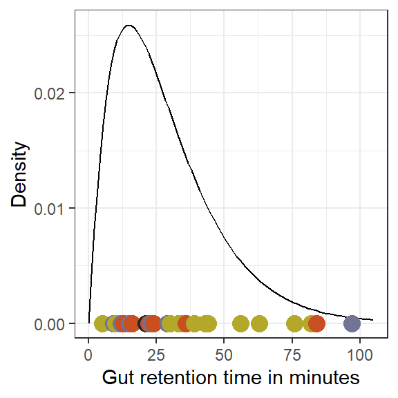

**Figure 3** - Description of gut retention times using field data for four individuals, shown by each dot along the x axis. The density curve fitted corresponds to a gamma distribution with parameters shape = 2.0562 and scale = 13. 8688. This gamma distribution is later used to sample gut retention times for simulations.

# Figure 4 - average dispersal and dispersion per run

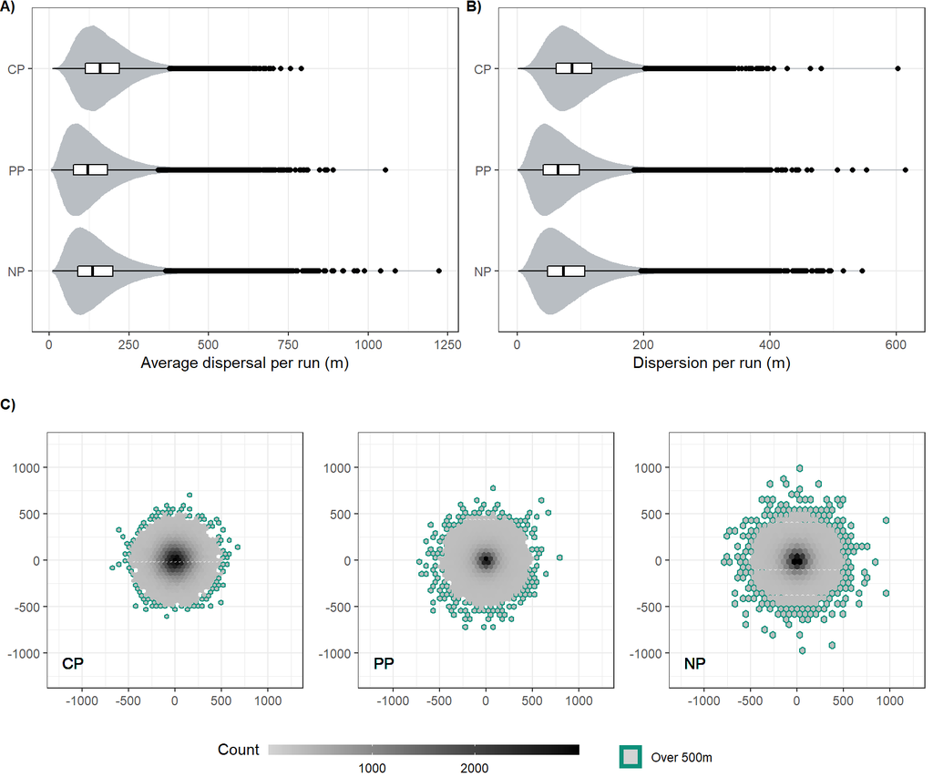

**Figure 4** - Average dispersal and dispersion for 100,000 simulation runs per pooling scenario. A) Dispersal per run is calculated as the distance from the origin to the average location of the 5 seeds in that run. The average seed location is then used to calculate dispersion as the distance of each seed to the average seed location in that run. Overall distribution of average dispersal is similar across scenarios, with differences in the density and location of outliers, with the furthest average dispersal at 1222m in the NP scenario. B) Seed dispersion per run in the three pooling scenarios. Higher values of dispersion represent more even distribution of seeds per simulation run. The overall distribution of dispersion data points is comparable across scenarios. When we focus on outliers, we observe a higher density of points past 400m of dispersion in the NP scenario, however the most extreme outliers belong to the PP, and CP scenarios. C) Average seed locations per simulation run. This two-dimensional representation of average seed locations shows a higher density close to the origin. Average seed locations over 500m from the origin are outlined in green, clearly showing a higher number of average locations outside this range for the NP scenario.

```
## # A tibble: 6 x 11
## # Groups:   model [3]
##   model property  mean    sd      n   min `0.25` `0.5` `0.75` `0.9`   max
##   <fct> <chr>    <dbl> <dbl>  <dbl> <dbl>  <dbl> <dbl>  <dbl> <dbl> <dbl>
## 1 CP    av.disp  175.   82.1 100000  10.5  114.  160.   219.   285.  790.
## 2 PP    av.disp  141.   89.4 100002   7     76.5 120.   182.   259. 1055.
## 3 NP    av.disp  157.   95.3  99990  10.1   89.3 135.   200.   280. 1222.
## 4 CP    dsprsn    93.9  44.2 100000   1.3   62.1  86.5  118.   153.  602.
## 5 PP    dsprsn    75.5  47.6 100002   1.5   41    64.5   98.4  138.  614.
## 6 NP    dsprsn    84.1  50.9  99990   2.1   48.1  72.5  107.   150.  546.
```

# Figure 5 - Dispersal kernels

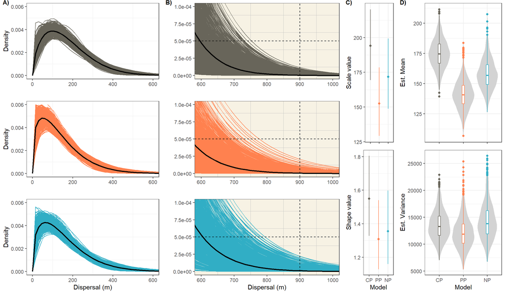

**Figure 5** - Estimated seed dispersal kernels and distribution of parameter values for the three pooling scenarios. A) Seed dispersal kernel curves for 1000 random samples of 100 seeds for each of the pooling scenarios based on fitting a Weibull probability density function to the data. B) Focus on the tails of the dispersal kernels, where the dashed lines are used for guiding purposes only. The NP scenario (blue) has a higher density of heavy tailed kernels, when compared to the other two scenarios. C) Each dispersal kernel is modeled using a Weibull distribution where estimated parameter values are obtained for each of the 1000 random samples. For the shape and scale parameters, we calculate the mean and their 95% confidence intervals generated from a non-parametric kernel density estimation to the 1000 parameter values obtained from the 1000 Weibull fits. D) Calculated expected value (mean) and variance for each of the kernel density curves using the scale and shape parameters obtained from the Weibull distribution fits. Overall distribution of variance for the three scenarios is similar, with the number and extent of outliers for the NP scenario being relatively higher.

# Table 2 - results

Summary table on seed dispersal distances for each of the pooling scenarios. For each of the scenarios, the metrics reported in this table are based on the 500,000 seeds deposited under each of the simulated scenarios.

| Model | Mean.dispersal_sd | kurtosis | Max_dispersal | LDD_500 |
| --- | --- | --- | --- | --- |
| CP | 174.5 (120) | 5.53 | 1344 | 1.878% |
| PP | 140.8 (120) | 8.74 | 1606 | 1.586% |
| NP | 156.8 (130) | 8.87 | 1716 | 2.23% |

# Appendix FIGURE 6 EVD generalized pareto results

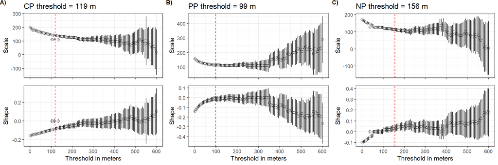

## Fit values

```
##           scale              shape
## [1,] "CP" "131.970849472812" "-0.086373693930297"
## [2,] "PP" "113.769080360959" "-0.0117591511580145"
## [3,] "NP" "118.696648099162" "0.0337757605938563"
```

## Find the conditional probabilities. Probability of exceeding a distance x, based on the fitted distribution

```
##            [,1]       [,2]      [,3]       [,4]         [,5]
## dist_range "Distance" "200"     "500"      "1000"       "5000"
##            "CP"       "0.53035" "0.035961" "4.7328e-05" "0"
##            "PP"       "0.41047" "0.027385" "0.00024586" "0"
##            "NP"       "0.69014" "0.062837" "0.001704"   "7.2267e-12"
```

## Summary for the fits

```
##
## fevd(x = cp.evd$disp, threshold = tval.cp, type = "GP")
##
## [1] "Estimation Method used: MLE"
##
##
##  Negative Log-Likelihood Value:  35610.29
##
##
##  Estimated parameters:
##        scale        shape
## 131.97084947  -0.08637369
##
##  Standard Error Estimates:
##       scale       shape
## 2.069113544 0.009172076
##
##  Estimated parameter covariance matrix.
##             scale         shape
## scale  4.28123086 -1.280157e-02
## shape -0.01280157  8.412698e-05
##
##  AIC = 71224.59
##
##  BIC = 71238.04
```

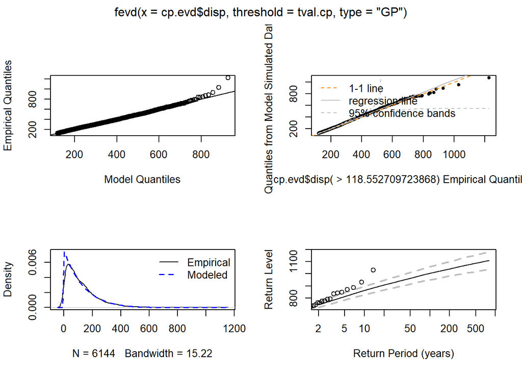

```
##
## fevd(x = pp.evd$disp, threshold = tval.pp, type = "GP")
##
## [1] "Estimation Method used: MLE"
##
##
##  Negative Log-Likelihood Value:  30798.06
##
##
##  Estimated parameters:
##        scale        shape
## 113.76908036  -0.01175915
##
##  Standard Error Estimates:
##      scale      shape
## 2.19089450 0.01360394
##
##  Estimated parameter covariance matrix.
##             scale         shape
## scale  4.80001871 -0.0213007617
## shape -0.02130076  0.0001850672
##
##  AIC = 61600.11
##
##  BIC = 61613.29
```

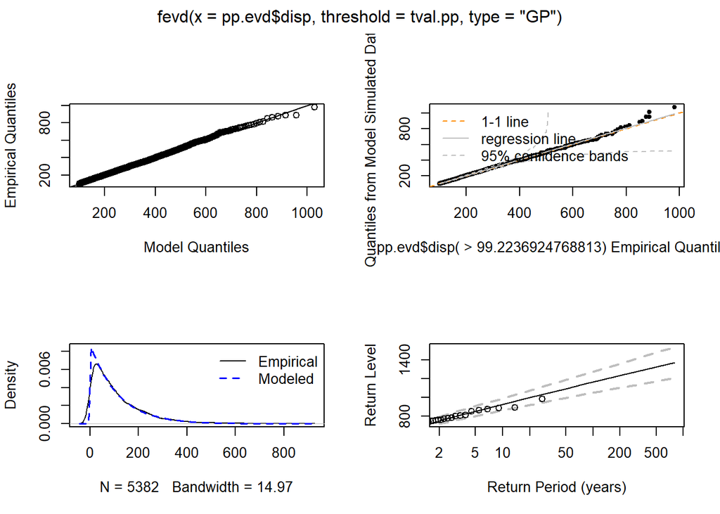

```
##
## fevd(x = np.evd$disp, threshold = tval.np, type = "GP")
##
## [1] "Estimation Method used: MLE"
##
##
##  Negative Log-Likelihood Value:  22567.22
##
##
##  Estimated parameters:
##        scale        shape
## 118.69664810   0.03377576
##
##  Standard Error Estimates:
##     scale     shape
## 2.6967446 0.0160921
##
##  Estimated parameter covariance matrix.
##             scale         shape
## scale  7.27243140 -0.0296719451
## shape -0.02967195  0.0002589558
##
##  AIC = 45138.44
##
##  BIC = 45150.97
```

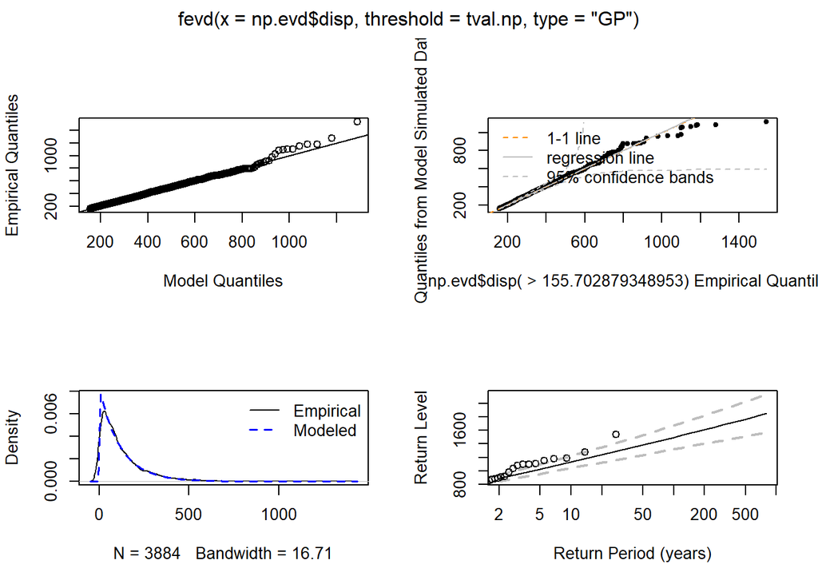